# Bookends 0.4

# Conclusion

**Overview**

Specialist and generalist predators differ in their degree of dependence on prey species, with cascading consequences for many aspects of their life history (Korpimaki and Norrdahl 1991, Resano‐Mayor et al. 2016). Specialist predators are efficient hunters of their main prey at the cost of poor success when hunting other species, whereas generalist predators hunt many species with equal skill (Terraube et al. 2011). A specialist predator may struggle to compensate with other prey when its main prey becomes scarce, but generalist predators readily switch to alternate prey (Steenhof and Kochert 1988, Terraube and Arroyo 2011). As a result, specialist predators depend on a single species and their demographic parameters–such as migration, reproductive success, and survival–vary in synchrony with its abundance (Korpimaki and Norrdahl 1991, Terraube et al. 2011). In contrast, generalist predators make use of many species and their populations are relatively stable (Andersson and Erlinge 1977, Hanski et al. 1991).

The familiar dichotomy between specialist and generalist predators is, of course, an oversimplification. The abundance of a single prey species can be a major driver of demographic parameters, such as reproductive success, for a generalist predator as well as a specialist one (Elmhagen et al. 2000, Resano‐Mayor et al. 2016). Furthermore, within a single species some populations (Salamolard et al. 2000, Roth et al. 2007), or some individuals within a population (Woo et al. 2008), may be more or less specialized. A single individual may also become more specialized over its lifetime as a result of age and experience (Rutz 2006). Correctly identifying the degree of specialization and understanding its effect on demographic parameters is more than a matter of theory or curiosity: the consequences of specialization can scale up from individuals through populations to entire species, with profound implications for conservation (Ferrer and Negro 2004, Terraube et al. 2011, Resano‐Mayor et al. 2016).

The complex relationship between dietary specialization and conservation is exemplified by the northern spotted owl. Spotted owls depend on old-growth forests, but the cause of this association has been a source of speculation from the earliest years of spotted owl research (Gutiérrez and Carey 1985). The association appears to be driven, in part, by the spotted owl’s relatively specialized diet (Carey et al. 1992, Ward et al. 1998). More than half the biomass spotted owls consume comes from just two taxa, flying squirrels (*Glaucomys sabrinus*) and woodrats (bushy-tailed woodrat *Neotoma cinerea* and dusky-footed woodrat *N. fuscipes*; reviewed in Carey et al. (1992)). This holds true across the subspecies’ range, although the relative contribution of each taxa varies with geographic region and forest type in response to local abundance. In Washington’s Olympic Peninsula, where woodrats are absent, spotted owls consume primarily flying squirrels (Carey et al. 1992), whereas in northern California flying squirrels make up a smaller portion of the diet and woodrats, which are more abundant, dominate (Ward et al. 1998). Even within a single spotted owl population some individuals specialize on one taxa or the other (Zabel et al. 1995). Home range sizes in the flying squirrel-dependent Olympic Peninsula are among the largest ever recorded (Carey et al. 1992), and where both taxa are present owls which consume primarily flying squirrels have larger home ranges than those which consume mostly woodrats (Zabel et al. 1995). Evidently diet and prey abundance affect some demographic parameters, such as breeding density, which has led some authors to recommend increasing prey abundance as a route to increase owl abundance (Forsman et al. 2004). Yet prey abundance does not appear to affect spotted owl productivity (Rosenberg et al. 2003). Instead, productivity appears to be the result of complex interactions between climate and prey abundance (Glenn et al. 2011).

In contrast to the spotted owl’s dependence on a few prey species, the northern goshawk is considered a generalist predator and consumes an enormous diversity of prey across its wide geographic range (reviewed in Drennan (2006); Rutz et al. (2006)). I identified 29 different prey species in the diet of goshawks in coastal British Columbia, which is consistent with a generalist foraging strategy. However, over 60% of goshawk diet in my study area was composed of tree squirrels (*Tamiasciurus* spp.), which indicates a level of specialization even greater than that of the spotted owl. Some goshawk populations appear to be strongly generalist (e.g. Arizona, Salafsky et al. (2007)), whereas in others a key prey species is a major driver of productivity, survival, and other demographic parameters (e.g. Yukon, Doyle and Smith (1994); and Finland, Tornberg et al. (2005)). I found no affect of the degree of dietary specialization on goshawk productivity. There are several explanations for this unexpected finding. First, specialists may not be more productive than generalists. Specialist individuals may preferentially consume tree squirrels but have similar levels of fitness as generalist individuals in this population (Woo et al. 2008). Alternately, specialization may not be the result of preference. Individuals may lack strong prey preferences and take tree squirrel in proportion to their abundance. Total prey abundance, rather than tree squirrel abundance, may drive productivity (Salafsky et al. 2007 ). Finally, as in the spotted owl, prey abundance and diet during the breeding season may be a lesser driver of productivity than other factors, such as weather or winter prey abundance.

**Directions for future research**

Comparing the foraging ecology of the northern spotted owl and the northern goshawk highlights significant knowledge gaps regarding goshawk biology. The controversy surrounding spotted owl conservation, combined with its position at the heart of a major management plan, has made it one of the most-studied birds in the world (Gutiérrez et al. 2020). The northern goshawk, although likewise shrouded in controversy, has not received the same level of study. Where data are available, it is more difficult to generalize research on the widespread, generalist northern goshawk than for the more restricted, relatively specialized spotted owl. As a result, there is a pressing need for detailed, local information on goshawks in the Pacific Northwest, particularly in coastal British Columbia.

One knowledge gap related to the work I present here is how variation in prey abundance affects the degree of dietary specialization, productivity, and survival of individual goshawks. Dietary specialization such as goshawks in my study area exhibit may be the result of a preference for the main prey or simply an absence of other options. Data on prey abundance is necessary to understand the mechanism of goshawk specialization and whether it is the result of high selectivity for tree squirrels, high abundance of tree squirrels, or some combination of both. This information could in turn be used to evaluate how changes in key prey abundance and total prey abundance influence goshawk demographic parameters, particularly productivity. Without this knowledge it is impossible to fully understand the factors limiting goshawk populations in coastal British Columbia.

A second knowledge gap is how the amount and type of habitat goshawks use for foraging varies with diet and prey abundance. Goshawk home range size varies across their geographic range and goshawks have been observed foraging in diverse habitat types, leading to ongoing debate over how and why goshawks select habitat (Greenwald et al. 2005, Reynolds et al. 2008). Research on spotted owls indicates that home range size is inversely related to prey abundance and foraging habitat selection varies with the identity of the main prey (Zabel et al. 1995). Variation in goshawk home range size and habitat selection may likewise be explained by diet and prey abundance (Kenward 1982, Penteriani et al. 2013). If so, foraging habitat management could only be conducted with knowledge of goshawk diet and recommendations made for one population could be applied to others only with great caution. Filling this knowledge gap with information specific to coastal British Columbia is vital and has been identified as a priority by goshawk managers (Team 2008, Agency 2018).

To address this crucial knowledge gap, the British Columbia Ministry of Forests, Lands, Natural Resource Operations and Rural Development (FLNRORD) and I conducted a pilot study of foraging habitat use in coastal British Columbia. Between 2018-2020 we tagged and tracked 4 male and 9 female goshawks. Captures were conducted during the early breeding season using a dho-gaza trap with a live great-horned owl (*Bubo virginianus*) as a lure (Bloom et al. 2007). Goshawks were fitted with 14-gram solar-powered GPS-UHF tags (Ecotone Telmetry brand, Harrier model) with an additional VHF tag, attached via a backpack-style harness. Tags were programmed to take a location point every 15 minutes and to download data to a base station when within range (approximately 100 m from the station). Base stations were placed beneath or above nests and tags checked for proximity to the station every 15 minutes.

We encountered several challenges over the course of the three-year pilot. First, the location data we obtained were biased toward females. Females are more aggressive near the nest than males and so are more likely to be captured when using the dho-gaza trapping method. Data from female tags downloaded more frequently onto the base stations than data from male tags because of the large amount of time females spent near the nest, where the base stations were located. Consequently, we collected far more location data on females than males, which offered relatively little insight into foraging habitat use since males provide most of the food during the breeding season. Second, we were able to relocate four of the six birds tagged in the first year only using the VHF tag. As a result, we could not download data from the winter or subsequent spring, and were never able relocated the remaining two birds. Our inability to relocate birds is likely due to a combination of the limited range of the VHF tags and the difficult topography of our study area, compounded by the birds’ failure to return to known breeding areas. Finally, technical failures resulted in no data downloads for two birds, too many location points for one birds, and too few location points for many others. Future work should consider more powerful VHF tags for easier relocation and an alternate-days duty cycle to reduce the number of missed locations.

**Management implications**

Climate change is one of the largest and most difficult to anticipate threats facing biodiversity (Bellard et al. 2012). The current understanding of how climate change will impact goshawks in coastal British Columbia is largely speculative (Agency 2018). Although I found no evidence of a link between the degree of dietary specialization and goshawk productivity, the level of specialization I observed and findings from other studies suggest goshawks in my study area are highly dependent on tree squirrels for successful reproduction. Notably, Ethier (1999) found goshawk productivity on Vancouver Island to be significantly correlated with red squirrel abundance. Tree squirrels are themselves highly dependent on conifer seeds and their abundance varies with the size of the annual cone crop (Smith 1970). Seed production is cyclical, but may be increased by higher temperatures and inhibited by drought (Boucher et al. 2020). As the climate warms and drought risk rises, climate-driven changes in seed production may cascade upward through prey abundance to impact goshawk populations in coastal British Columbia. Significantly more work is needed to understand the relationship between prey abundance, the buffering ability of alternate prey, and goshawk productivity, but my results provide an important starting point for incorporating climate change into goshawk management.

Wildlife management, whether rooted in a single-species or ecosystem-based approach, generally centers around species, subspecies, or unique populations at risk of extinction. My thesis examines a single population of goshawks on the south coast of British Columbia which is currently classified as part of the subspecies *laingi*. The precise range of *laingi* has always been unclear, but recent genetic evidence calls into question the boundaries currently used in goshawk management. Geraldes et al. (2018) identified the Haida Gwaii population as highly unique and distinct from populations on Vancouver Island and the mainland coast. Their findings indicate the distribution of *laingi* may be restricted to Haida Gwaii and challenge the conservation status of goshawk populations elsewhere within the putative range of *laingi*. My results suggest a strong ecological similarity between goshawks within my study area, Vancouver Island, and Haida Gwaii, where goshawks are also highly dependent on tree squirrels (COSEWIC 2013). The diet of these populations stands in contrast to others in temperate rainforest ecosystems which are currently considered *laingi*, such as the Olympic Peninsula or Southeast Alaska, where goshawks consume mainly birds. Goshawks in coastal British Columbia are further different from populations elsewhere in western North America, where goshawks also consume primarily mammals but do not specialize on tree squirrels. Goshawks in coastal British Columbia may therefore be ecologically similar to each other, and ecologically distinct from other populations, even if they are genetically dissimilar. Ecological similarity does not indicate a single, uniform management strategy is appropriate for all goshawks in the region: red squirrels, for instance, are an introduced species on Haida Gwaii. However, it does demonstrate that management plans benefit from the type of fine-scale ecological information my thesis provides. Further, their ecological similarity suggests these goshawks may deserve special management consideration as a population unique to the temperate rainforests of coastal British Columbia.

# Figures

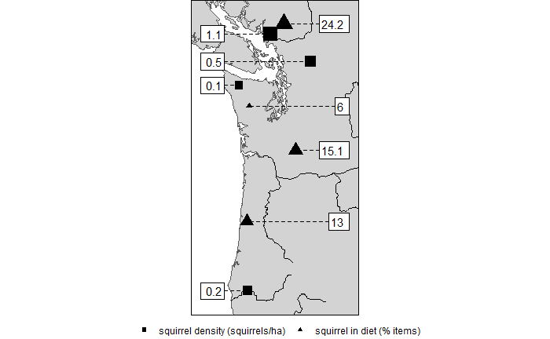

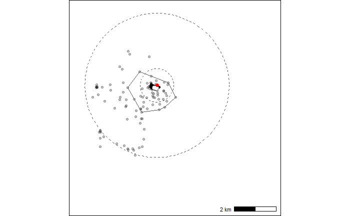

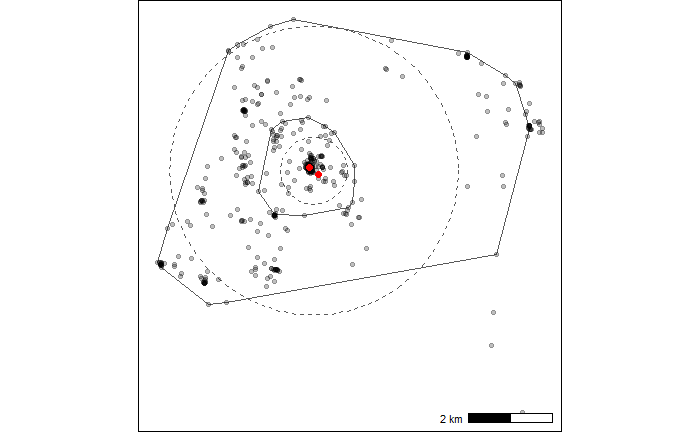

| ID | Site | Days of data collected first | Days of data collected last | Days of data collected N. days | Relation to nest N. points | Relation to nest Max. distance from nest (m) | Relation to nest % points taken at nest | Home range (ha) 50% MCP | Home range (ha) 95% MCP | Home range (ha) 50% KDE | Home range (ha) 95% KDE |
| --- | --- | --- | --- | --- | --- | --- | --- | --- | --- | --- | --- |
| HAR12 | FMT | 2020-06-25 | 2020-06-28 | 3 | 104 | 2.3 | 3.9 | 0.7 | 103.7 | 13 | 152.1 |
| HAR03 | GRV | 2020-06-08 | 2020-06-28 | 20 | 2964 | 2.4 | 95.9 | 0 | 0 | 0 | 0 |
| HAR10 | MTC | 2019-05-02 | 2019-06-29 | 58 | 315 | 5.5 | 78.4 | 0.3 | 58.9 | 8.7 | 113.4 |
| HAR02 | RLK | 2020-06-13 | 2020-07-08 | 25 | 977 | 4 | 72.1 | 5.4 | 280.6 | 12.7 | 267.4 |
| HAR08 | TCR | 2019-06-10 | 2019-06-27 | 17 | 45 | 0.1 | 82.2 | 0 | 0.2 | 0 | 0.4 |
| AVERAGE | - | - | - | 25 | - | 2.9 | 66.5 | 1.3 | 88.7 | 6.9 | 106.7 |
| HAR09 | MTC | 2019-05-02 | 2019-07-02 | 61 | 409 | 4.4 | 2.4 | 530.1 | 2611.2 | 636.3 | 3032.8 |
| HAR04 | RLK | 2019-06-22 | 2019-07-08 | 16 | 532 | 7.8 | 9 | 423 | 4441.1 | 662.3 | 4407.6 |
| HAR05 | SKA | 2019-06-23 | 2019-09-04 | 73 | 1557 | 8 | 0 | 1548.2 | 6052.9 | 1642.2 | 6674.7 |
| HAR07 | TCR | 2018-07-08 | 2018-09-14 | 68 | 637 | 8 | 0 | 904.8 | 4531.4 | 850.6 | 5263.1 |
| AVERAGE | - | - | - | 54 | - | 7 | 2.9 | 851.5 | 4409.2 | 947.9 | 4844.5 |

Agency, P. C. 2018. Recovery Strategy for the Northern Goshawk laingi subspecies (*Accipiter gentilis laingi*) in Canada. Volume 1. Species at Risk Act Recovery Strategy Series, Parks Canada Agency, Ottawa.

Andersson, M., and S. Erlinge. 1977. Influence of Predation on Rodent Populations. Oikos 29:591–597. <http://www.jstor.org/stable/3543597>. Accessed 10 May 2021.

Bloom, P. H., W. S. Clark, and J. W. Kidd. 2007. Capture Techniques. Pages 193–219 *in* D. M. Bird and K. L. Bildstein, editors. Raptor Research and Management Techniques. Second edition. Hancock House Publishers, Blaine, WA, USA.

Bloxton, T. D., Jr. 2002. Prey Abundance, Space Use, Demography, and Foraging Habitat of Northern Goshawks in Western Washington. Master’s thesis, University of Washington, Seattle, WA.

Boucher, D., S. Gauthier, N. Thiffault, W. Marchand, M. Girardin, and M. Urli. 2020. How climate change might affect tree regeneration following fire at northern latitudes: A review. New Forests 51:543–571.

Carey, A. B. 1995. Sciurids in Pacific Northwest Managed and Old-Growth Forests. Ecological Applications 5:648–661. <http://www.jstor.org/stable/1941974>. Accessed 6 Jan 2021.

Carey, A. B., S. P. Horton, and B. L. Biswell. 1992. Northern Spotted Owls: Influence of Prey Base and Landscape Character. Ecological Monographs 62:223–250. <http://www.jstor.org/stable/2937094>. Accessed 25 Jan 2019.

COSEWIC. 2013. COSEWIC assessment and status report on the Northern Goshawk *Accipiter gentilis laingi* in Canada. Committee on the Status of Endangered Wildlife in Canada, Ottawa, ON. <[http://www.sararegistry.gc.ca/virtual_sara/files/cosewic/sr_autour _palombes_northern_goshawk_1213_e.pdf](http://www.sararegistry.gc.ca/virtual_sara/files/cosewic/sr_autour%20_palombes_northern_goshawk_1213_e.pdf)>.

Doyle, F. I., and J. M. N. Smith. 1994. Population responses of northern goshawks to the 10-year cycle in numbers of snowshoe hares. Studies in Avian Biology 16:122–129.

Drennan, J. E. 2006. Northern goshawk food habits and goshawk prey species habitats. Studies in Avian Biology 31:198–218.

Elmhagen, B., M. Tannerfeldt, P. Verucci, and A. Angerbjörn. 2000. The arctic fox (*Alopex lagopus*): An opportunistic specialist. Journal of Zoology 251:139–149. <http://zslpublications.onlinelibrary.wiley.com/doi/abs/10.1111/j.1469-7998.2000.tb00599.x>. Accessed 15 Dec 2020.

Ethier, T. J. 1999. Breeding Ecology and Habitat of Northern Goshawks (*Accipiter gentilis laingi*) on Vancouver Island: A Hierarchical Approach. PhD, University of Victoria, Victoria, BC.

Ferrer, M., and J. J. Negro. 2004. The Near Extinction of Two Large European Predators: Super Specialists Pay a Price. Conservation Biology 18:344–349. <http://conbio.onlinelibrary.wiley.com/doi/abs/10.1111/j.1523-1739.2004.00096.x>. Accessed 15 Dec 2020.

Forsman, E. D., R. G. Anthony, E. C. Meslow, and C. J. Zabel. 2004. Diets and Foraging Behavior of Northern Spotted Owls in Oregon. Journal of Raptor Research 38:214–230.

Geraldes, A., K. K. Askelson, E. Nikelski, F. I. Doyle, W. L. Harrower, K. Winker, and D. E. Irwin. 2018. Population genomic analyses reveal a highly differentiated and endangered genetic cluster of northern goshawks (*Accipiter gentilis laingi*) in Haida Gwaii. Evolutionary Applications 1–16. <https://onlinelibrary.wiley.com/doi/abs/10.1111/eva.12754>. Accessed 15 Jan 2019.

Glenn, E. M., R. G. Anthony, E. D. Forsman, and G. S. Olson. 2011. Reproduction of northern spotted owls: The role of local weather and regional climate. The Journal of Wildlife Management 75:1279–1294. <http://wildlife.onlinelibrary.wiley.com/doi/abs/10.1002/jwmg.177>. Accessed 3 May 2021.

Greenwald, N. D., D. C. Crocker-Bedford, L. Broberg, K. F. Suckling, and T. Tibbitts. 2005. A review of northern goshawk habitat selection in the home range and implications for forest management in the western United States. Wildlife Society Bulletin 33:120–129.

Gutiérrez, R. J., and A. B. Carey, editors. 1985. Ecology and management of the spotted owl in the Pacific Northwest. Gen. Tech. Rep. PNW-185, U.S. Department of Agriculture, Forest Service, Pacific Northwest Forest; Range Experiment Station, Portland, OR, USA.

Gutiérrez, R. J., A. B. Franklin, and W. S. LaHaye. 2020. Spotted owl (*Strix occidentalis*), verion 1.0. A. F. Poole and F. B. Gill, editors. Birds of the World. Cornell Lab of Ornithology, Ithaca, NY, USA.

Hanski, I., L. Hansson, and H. Henttonen. 1991. Specialist Predators, Generalist Predators, and the Microtine Rodent Cycle. Journal of Animal Ecology 60:353–367. <http://www.jstor.org/stable/5465>. Accessed 10 May 2021.

Kenward, R. 1982. Goshawk hunting behaviour and range size as a function of food and habitat availability. The Journal of Animal Ecology 51:69.

Korpimaki, E., and K. Norrdahl. 1991. Numerical and Functional Responses of Kestrels, Short-Eared Owls, and Long-Eared Owls to Vole Densities. Ecology 72:814–826. <http://www.jstor.org/stable/1940584>. Accessed 24 Dec 2020.

Lewis, S. B., K. Titus, and M. R. Fuller. 2006. Northern goshawk diet during the nesting season in southeast Alaska. The Journal of Wildlife Management 70:1151–1160. <https://onlinelibrary.wiley.com/doi/abs/10.2193/0022-541X%282006%2970%5B1151%3ANGDDTN%5D2.0.CO%3B2>. Accessed 4 Sep 2018.

Penteriani, V., C. Rutz, and R. Kenward. 2013. Hunting behaviour and breeding performance of northern goshawks Accipiter gentilis, in relation to resource availability, sex, age and morphology. Naturwissenschaften 100:935–942. <https://doi.org/10.1007/s00114-013-1093-7>. Accessed 12 May 2019.

Ransome, D. B., and T. P. Sullivan. 2003. Population dynamics of Glaucomys sabrinus and Tamiasciurus douglasii in old-growth and second-growth stands of coastal coniferous forest. Canadian Journal of Forest Research 33:587–596. <https://cdnsciencepub-com.proxy.lib.sfu.ca/doi/abs/10.1139/x02-193>. Accessed 6 Jan 2021.

Resano‐Mayor, J., J. Real, M. Moleón, J. A. Sánchez‐Zapata, L. Palma, and A. Hernández‐Matías. 2016. Diet–demography relationships in a long‐lived predator: From territories to populations. Oikos 125:262–270. <https://onlinelibrary-wiley-com.proxy.lib.sfu.ca/doi/10.1111/oik.02468>. Accessed 14 Dec 2020.

Reynolds, R. T., R. T. Graham, and D. A. Boyce. 2008. Northern goshawk habitat: An intersection of science, management, and conservation. The Journal of Wildlife Management 72:1047–1055. <http://onlinelibrary.wiley.com/doi/abs/10.2193/2007-131>. Accessed 3 Oct 2018.

Rosenberg, D. K., K. A. Swindle, and R. G. Anthony. 2003. Influence of prey abundance on northern spotted owl reproductive success in western Oregon. Canadian Journal of Zoology 81:1715–1725. <https://cdnsciencepub-com.proxy.lib.sfu.ca/doi/abs/10.1139/z03-167>. Accessed 3 May 2021.

Roth, J. D., J. D. Marshall, D. L. Murray, D. M. Nickerson, and T. D. Steury. 2007. Geographicgradients in Diet Affect Population Dynamics of Canada Lynx. Ecology 88:2736–2743. <http://esajournals.onlinelibrary.wiley.com/doi/abs/10.1890/07-0147.1>. Accessed 10 May 2021.

Rutz, C. 2006. Home range size, habitat use, activity patterns and hunting behaviour of urban-breeding Northern Goshawks *Accipiter gentilis*. ARDEA 94:185–202.

Rutz, C., R. G. Bijlsma, M. Marquiss, and R. E. Kenward. 2006. Population limitation in the Northern Goshawk in Europe: A review with case studies. Studies in Avian Biology 31:158–197.

Salafsky, S. R., R. T. Reynolds, B. R. Noon, and J. A. Wiens. 2007. Reproductive Responses of Northern Goshawks to Variable Prey Populations. The Journal of Wildlife Management 71:2274–2283. <http://wildlife.onlinelibrary.wiley.com/doi/abs/10.2193/2006-357>. Accessed 3 Sep 2020.

Salamolard, M., A. Butet, A. Leroux, and V. Bretagnolle. 2000. Responses of an Avian Predator to Variations in Prey Density at a Temperate Latitude. Ecology 81:2428–2441. <http://esajournals.onlinelibrary.wiley.com/doi/abs/10.1890/0012-9658%282000%29081%5B2428%3AROAAPT%5D2.0.CO%3B2>. Accessed 10 May 2021.

Smith, C. C. 1970. The Coevolution of Pine Squirrels (Tamiasciurus) and Conifers. Ecological Monographs 40:349–371. <http://www.jstor.org/stable/1942287>. Accessed 14 May 2021.

Steenhof, K., and M. N. Kochert. 1988. Dietary responses of three raptor species to changing prey densities in a natural environment. Journal of Animal Ecology 57:37–48. <http://www.jstor.org/stable/4761>. Accessed 1 Apr 2019.

Team, N. G. R. 2008. Recovery strategy for the Northern Goshawk, laingi subspecies (Accipiter gentilis laingi) in British Columbia. B.C. Ministry of Environment, Victoria, BC. <http://a100.gov.bc.ca/pub/eirs/viewDocumentDetail.do?fromStatic=true&repository=BDP&documentId=7811>.

Terraube, J., and B. Arroyo. 2011. Factors influencing diet variation in a generalist predator across its range distribution. Biodiversity and Conservation 20:2111–2131. <https://doi.org/10.1007/s10531-011-0077-1>. Accessed 29 Apr 2019.

Terraube, J., B. Arroyo, M. Madders, and F. Mougeot. 2011. Diet specialisation and foraging efficiency under fluctuating vole abundance: A comparison between generalist and specialist avian predators. Oikos 120:234–244. <http://www.jstor.org/stable/29783506>. Accessed 7 Dec 2020.

Thrailkill, J. A., L. S. Andrews, and R. M. Claremont. 2000. Diet of Breeding Northern Goshawks in the Coast Range of Oregon. Journal of Raptor Research 34:339–340.

Tornberg, R., E. Korpimäki, S. Jungell, and V. Reif. 2005. Delayed numerical response of goshawks to population fluctuations of forest grouse. Oikos 111:408–415.

Ward, J. P., R. J. Gutiérrez, and B. R. Noon. 1998. Habitat Selection by Northern Spotted Owls: The Consequences of Prey Selection and Distribution. The Condor 100:79–92. <https://www.jstor.org/stable/1369899>. Accessed 6 May 2020.

Watson, J. W., D. W. Hays, S. P. Finn, and P. Meehan. 1998. Prey of breeding northern goshawks in Washington. Journal of Raptor Research 32:397–305.

Woo, K. J., K. H. Elliott, M. Davidson, A. J. Gaston, and G. K. Davoren. 2008. Individual specialization in diet by a generalist marine predator reflects specialization in foraging behaviour. Journal of Animal Ecology 77:1082–1091. <http://besjournals.onlinelibrary.wiley.com/doi/abs/10.1111/j.1365-2656.2008.01429.x>. Accessed 11 May 2021.

Zabel, C. J., K. McKelvey, and J. P. Ward Jr. 1995. Influence of primary prey on home-range size and habitat-use patterns of northern spotted owls (Strix occidentalis caurina). Canadian Journal of Zoology 73:433–439. <http://www.nrcresearchpress.com/doi/abs/10.1139/z95-049>. Accessed 16 May 2019.